# Data 612 - Project 1

Paul Perez

6/9/2020

## The Recommender System

This system recommends movie’s to film enthusiasts using the MovieLens `ml-latest-small` dataset. This set contains 100,836 ratings which spans 610 users, 9742 movies and 3,683 tag applications.The data is contained within 4 csv files; `links.csv`, `ratings.csv`, `movies.csv`, and `tags.csv`. To simplify the system in this project, we’ll only be joining the `ratings.csv` and `movies.csv` on `movieId` field.

## Data Ingestion, Selection, Manipulation

```r
movies <- read.csv('https://raw.githubusercontent.com/ChefPaul/data612/master/Project%201/movies.csv')
ratings <- read.csv('https://raw.githubusercontent.com/ChefPaul/data612/master/Project%201/ratings.csv')
```

### Preview of Movies & Ratings datasets

```r
head(movies)
```

|  | movieId | title | genres |
| --- | --- | --- | --- |
| 1 | 1 | Toy Story (1995) | Adventure\|Animation\|Children\|Comedy\|Fantasy |
| 2 | 2 | Jumanji (1995) | Adventure\|Children\|Fantasy |
| 3 | 3 | Grumpier Old Men (1995) | Comedy\|Romance |
| 4 | 4 | Waiting to Exhale (1995) | Comedy\|Drama\|Romance |
| 5 | 5 | Father of the Bride Part II (1995) | Comedy |
| 6 | 6 | Heat (1995) | Action\|Crime\|Thriller |

```r
head(ratings)
```

|  | userId | movieId | rating | timestamp |
| --- | --- | --- | --- | --- |
| 1 | 1 | 1 | 4 | 964982703 |
| 2 | 1 | 3 | 4 | 964981247 |
| 3 | 1 | 6 | 4 | 964982224 |
| 4 | 1 | 47 | 5 | 964983815 |
| 5 | 1 | 50 | 5 | 964982931 |
| 6 | 1 | 70 | 3 | 964982400 |

### Join Movies & Ratings datasets

```r
joined_data <- full_join(ratings, movies, by = 'movieId')
joined_data_preview <- head(joined_data, 10)
joined_data_preview %>% kable(caption = "Joined Data Preview") %>% kable_styling("striped", full_width = TRUE)
```

Joined Data Preview

| userId | movieId | rating | timestamp | title | genres |
| --- | --- | --- | --- | --- | --- |
| 1 | 1 | 4 | 964982703 | Toy Story (1995) | Adventure\|Animation\|Children\|Comedy\|Fantasy |
| 1 | 3 | 4 | 964981247 | Grumpier Old Men (1995) | Comedy\|Romance |
| 1 | 6 | 4 | 964982224 | Heat (1995) | Action\|Crime\|Thriller |
| 1 | 47 | 5 | 964983815 | Seven (a.k.a. Se7en) (1995) | Mystery\|Thriller |
| 1 | 50 | 5 | 964982931 | Usual Suspects, The (1995) | Crime\|Mystery\|Thriller |
| 1 | 70 | 3 | 964982400 | From Dusk Till Dawn (1996) | Action\|Comedy\|Horror\|Thriller |
| 1 | 101 | 5 | 964980868 | Bottle Rocket (1996) | Adventure\|Comedy\|Crime\|Romance |
| 1 | 110 | 4 | 964982176 | Braveheart (1995) | Action\|Drama\|War |
| 1 | 151 | 5 | 964984041 | Rob Roy (1995) | Action\|Drama\|Romance\|War |
| 1 | 157 | 5 | 964984100 | Canadian Bacon (1995) | Comedy\|War |

### Slice dataset to only contain UserId, Movie Title, and Movie Rating

```r
data <- joined_data[,c(1,5,3)]
data_preview <- head(data, 10)
data_preview  %>% kable(caption = "Sliced Dataset Preview") %>% kable_styling("striped", full_width = TRUE)
```

Sliced Dataset Preview

| userId | title | rating |
| --- | --- | --- |
| 1 | Toy Story (1995) | 4 |
| 1 | Grumpier Old Men (1995) | 4 |
| 1 | Heat (1995) | 4 |
| 1 | Seven (a.k.a. Se7en) (1995) | 5 |
| 1 | Usual Suspects, The (1995) | 5 |
| 1 | From Dusk Till Dawn (1996) | 3 |
| 1 | Bottle Rocket (1996) | 5 |
| 1 | Braveheart (1995) | 4 |
| 1 | Rob Roy (1995) | 5 |
| 1 | Canadian Bacon (1995) | 5 |

### Identify Top 5 Most Rated Movies

In order to create a sparse dataset, but still ensure we have a sufficient number of ratings, we’ll have to identify the Top 5 movies that were the most frequently rated.

```r
# top 5 movies
movie_freq <- table(joined_data$title) %>% as.data.frame() %>% arrange(desc(Freq))
top_5 <- movie_freq[1:5,][1]
top_5  %>% kable(caption = "Top 5 Frequently Rated Movies Preview") %>% kable_styling("striped", full_width = TRUE)
```

Top 5 Frequently Rated Movies Preview

| Var1 |
| --- |
| Forrest Gump (1994) |
| Shawshank Redemption, The (1994) |
| Pulp Fiction (1994) |
| Silence of the Lambs, The (1991) |
| Matrix, The (1999) |

Now that we’ve identified the most frequently rated movies, we can filter the dataset to only contain these movies.

```r
sub_data <- data %>% filter(title %in% c("Forrest Gump (1994)", "Shawshank Redemption, The (1994)", "Pulp Fiction (1994)", "Silence of the Lambs, The (1991)", "Matrix, The (1999)"))
sub_data_preview <- head(sub_data, 10)
sub_data_preview  %>% kable(caption = "Subset of Data Preview") %>% kable_styling("striped", full_width = TRUE)
```

Subset of Data Preview

| userId | title | rating |
| --- | --- | --- |
| 1 | Pulp Fiction (1994) | 3 |
| 1 | Forrest Gump (1994) | 4 |
| 1 | Silence of the Lambs, The (1991) | 4 |
| 1 | Matrix, The (1999) | 5 |
| 2 | Shawshank Redemption, The (1994) | 3 |
| 4 | Pulp Fiction (1994) | 1 |
| 4 | Silence of the Lambs, The (1991) | 5 |
| 4 | Matrix, The (1999) | 1 |
| 5 | Pulp Fiction (1994) | 5 |
| 5 | Shawshank Redemption, The (1994) | 3 |

Finally, since we have a subset of the data, we can create a user-item matrix utilizing the `spread()` function from the `tidyr` package.

```r
wide_data <- sub_data %>% spread(title, rating)
wide_data_preview <- head(wide_data)
wide_data_preview %>% kable(caption = "User-Item Matrix Preview") %>% kable_styling("striped", full_width = TRUE)
```

User-Item Matrix Preview

| userId | Forrest Gump (1994) | Matrix, The (1999) | Pulp Fiction (1994) | Shawshank Redemption, The (1994) | Silence of the Lambs, The (1991) |
| --- | --- | --- | --- | --- | --- |
| 1 | 4 | 5 | 3 | NA | 4 |
| 2 | NA | NA | NA | 3 | NA |
| 4 | NA | 1 | 1 | NA | 5 |
| 5 | NA | NA | 5 | 3 | NA |
| 6 | 5 | NA | 2 | 5 | 4 |
| 7 | 5 | NA | NA | NA | 5 |

## Split into Training & Test datasets using an 80/20 Ratio

We can utilize the `sample()` function to split the data into training and test sets.

```r
set.seed(123)
train_sample <- sample(x = c(TRUE, FALSE), size = nrow(wide_data), replace = TRUE, prob = c(0.8, 0.2))
train_id <- as.matrix(wide_data[train_sample,])
test_id <- as.matrix(wide_data[!train_sample,])
```

While splitting, the `userId` field will remain within the matrix, but we can remove that to further build out the system and run calculations on each matrix.

```r
train <- train_id[,2:6]
train_preview <- head(train)
train_preview %>% kable(caption = "Training User-Item Matrix Preview") %>% kable_styling("striped", full_width = TRUE)
```

Training User-Item Matrix Preview

|  | Forrest Gump (1994) | Matrix, The (1999) | Pulp Fiction (1994) | Shawshank Redemption, The (1994) | Silence of the Lambs, The (1991) |
| --- | --- | --- | --- | --- | --- |
| 1 | 4 | 5 | 3 | NA | 4 |
| 2 | NA | NA | NA | 3 | NA |
| 3 | NA | 1 | 1 | NA | 5 |
| 6 | 5 | NA | NA | NA | 5 |
| 7 | 3 | NA | 4 | 5 | 4 |
| 9 | 5 | NA | NA | 4 | 5 |

```r
test <- test_id[,2:6]
test_preview <- head(test)
test_preview %>% kable(caption = "Testing User-Item Matrix Preview") %>% kable_styling("striped", full_width = TRUE)
```

Testing User-Item Matrix Preview

|  | Forrest Gump (1994) | Matrix, The (1999) | Pulp Fiction (1994) | Shawshank Redemption, The (1994) | Silence of the Lambs, The (1991) |
| --- | --- | --- | --- | --- | --- |
| 4 | NA | NA | 5 | 3.0 | NA |
| 5 | 5.0 | NA | 2 | 5.0 | 4.0 |
| 8 | 3.5 | 0.5 | 1 | NA | NA |
| 11 | 4.0 | NA | 3 | 3.0 | 4.0 |
| 16 | 2.0 | 4.0 | NA | NA | NA |
| 20 | 4.5 | 4.0 | 4 | 4.5 | 4.5 |

## Calculate the Raw Average (Training Set)

We’ll need to calculate the raw average (mean) for each user-item combination in the training set.

```r
raw_avg <- mean(as.matrix(train), na.rm = TRUE)
```

## RMSE for Raw Average

Since we’re going to have to calculate the RMSE multiple times, we can create the function below.

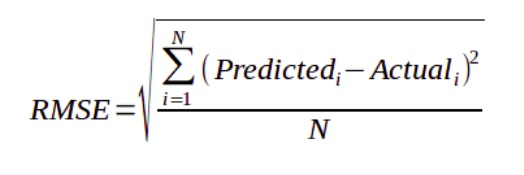

RMSE Formula

```r
rmse <- function(m, o){
  sqrt(mean((m - o)^2, na.rm = TRUE))
}
```

### Training Set RMSE

```r
train_rmse <- rmse(raw_avg, train)
train_rmse
```

```
## [1] 0.848821
```

### Test Set RMSE

```r
test_rmse <- rmse(raw_avg, test)
test_rmse
```

```
## [1] 0.959381
```

## User & Item Bias from Training Set

Now that we have the mean for the training set, we can calculate each user & item bias.

```r
user_bias <- rowMeans(train, na.rm = TRUE) - raw_avg
item_bias <- colMeans(train, na.rm = TRUE) - raw_avg
```

### Calculating the Baseline Predictors

```r
baseline_predictors <- user_bias + item_bias + raw_avg
```

```r
baseline_predictors[baseline_predictors < 1] <- 1
baseline_predictors[baseline_predictors > 5] <- 5
```

### Calculating the RMSE for the Basline Predictors of the Training Set

```r
train_baseline_rmse <- rmse(raw_avg, baseline_predictors)
```

## Calculate the Raw Average (Test Set)

We’ll need to calculate the raw average (mean) for each user-item combination in the test set.

```r
test_avg <- mean(as.matrix(test), na.rm = TRUE)
```

Now that we have the mean for the test set, we can calculate each user & item bias.

```r
test_user_bias <- rowMeans(test, na.rm = TRUE) - test_avg
test_item_bias <- colMeans(test, na.rm = TRUE) - test_avg
```

### Calculating the Baseline Predictors

```r
test_baseline_predictors <- test_avg + test_item_bias + test_user_bias
```

```r
test_baseline_predictors[test_baseline_predictors < 1] <- 1
test_baseline_predictors[test_baseline_predictors > 5] <- 5
```

### Calculating the RMSE for the Basline Predictors of the Test Set

```r
test_baseline_rmse <- rmse(test_avg, test_baseline_predictors)
```

## Summary

```r
test_eval <- (1 - (test_baseline_rmse / test_rmse)) * 100
test_eval
```

```
## [1] 24.96047
```

```r
train_eval <- (1 - (train_baseline_rmse / train_rmse)) * 100
train_eval
```

```
## [1] 19.83473
```

After creating the recommender system, we can see that the test evaluation show’s a 24.96% improvement while the training set’s evaluation shows a 19.83% improvement.

### References

F. Maxwell Harper and Joseph A. Konstan. 2015. The MovieLens Datasets: History and Context. ACM Transactions on Interactive Intelligent Systems (TiiS) 5, 4: 19:1–19:19. https://doi.org/10.1145/2827872

#### Source Code

[GitHub Repository](https://github.com/ChefPaul/data612/tree/master/Project%201)